# ProblemSet2

Amy Richardson

2/23/2021

## Problem Set 1 - Quantitative Analysis

Working in:  
C:-Users-Amy Richardson-Dropbox-VT - PhD-ENGE 5714 - Quant-R Practice-ENGE5714-Problem Set 2

GitHub [link](https://github.com/AmyRichardsonVT/ENGE5714/blob/main/Problem%20Set%202/ProblemSet2.Rmd) to Code

```r
library(car)
library(psych)
library(ggplot2)
library(tidyverse)
library(broom)
```

# ——Part 1——

Create a correlation table between %2Y All, %4Y All, %4EngTot4yr, and %CSSTEMH4yr. In text, report which correlations are statistically significant (if any) and comment on the strength of any relationships you observe. Run parametric and non-parametric versions.

Read in Data and Create a DataFrame of salient columns.

```r
all_degrees <- read.csv("PS_Degrees.csv", header = TRUE)

names(all_degrees)[1] <- "div_name"
percent_degrees <- all_degrees %>%
  select("Div_num", "X.2r", "X.4yr", "X.EngTot4yr", "X.CSSTEMH4yr" ) %>%
  transform(X.2r = X.2r * 100) %>%
  transform(X.4yr = X.4yr * 100) %>%
  transform(X.EngTot4yr = X.EngTot4yr * 100) %>%
  transform(X.CSSTEMH4yr = X.CSSTEMH4yr * 100)
```

- Define variables:
  - X.2r = Percent of total degrees awarded from 2-yr public VA institutions, 2012-13 through 2016-17
  - X.4yr = Percent of total degrees awarded from 4-yr institutions, 2012-13 through 2016-17
  - X.EngTot4yr = Percent of total degrees from 4-yr institutions during five-year time period that were Engineering degrees
  - X.CSSTEMH4yr = Percent of all STEMH degrees awarded from 4-yr institutions that were CS/IS during five-year time period

Remove rows with NA since the entire row contains NA values

```r
percent_degrees <- percent_degrees[-c(135:144), ]
```

Check to see if the data is normally distributed. First Plot this data.

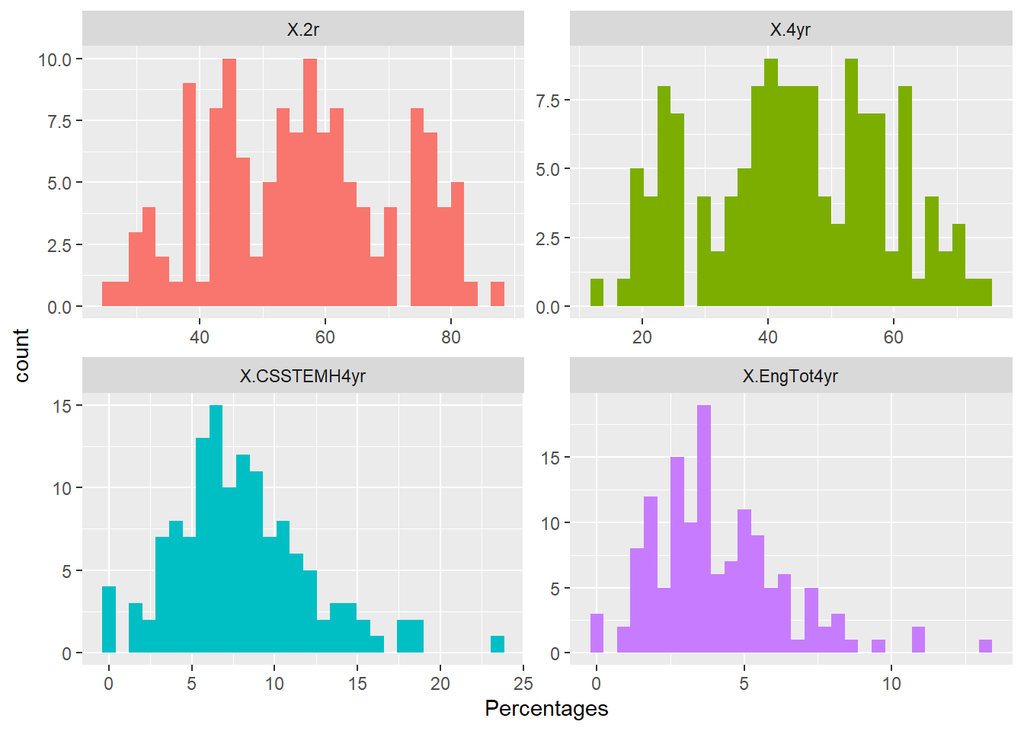

```r
degree_df_long <- percent_degrees %>%
  pivot_longer(cols = X.2r:X.CSSTEMH4yr, names_to = "Variable", values_to = "Percentages")

degree_df_long %>%
  ggplot(aes(x = Percentages, fill = Variable)) +
  geom_histogram() +
  facet_wrap(Variable ~., scales = "free") +
  theme(legend.position = "none")
```

Run Q-QPlots

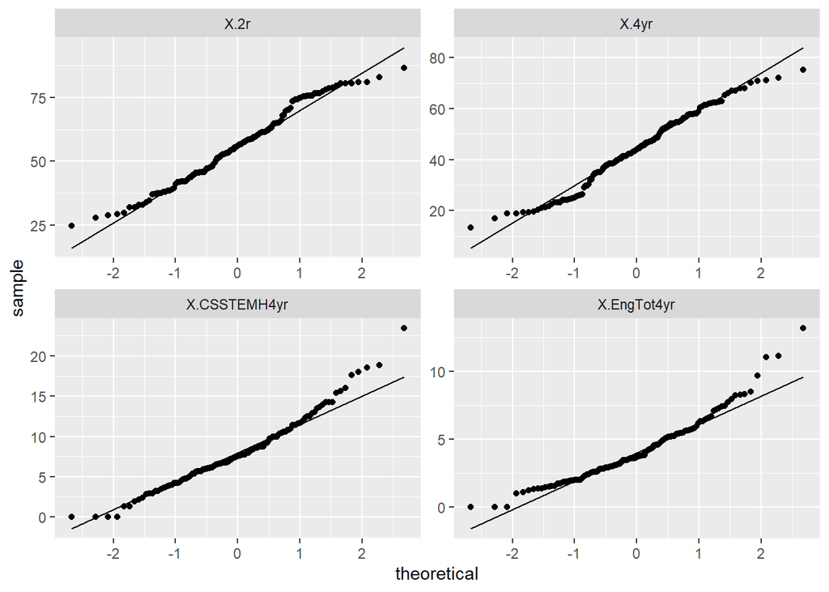

```r
degree_df_long %>%
  ggplot(aes(sample=Percentages)) +
  stat_qq() +
  stat_qq_line() +
  facet_wrap(Variable ~ ., scales = "free")
```

Run correlation

```r
my_correlations <- percent_degrees %>% select(X.2r, X.4yr, X.EngTot4yr, X.CSSTEMH4yr) %>% cor()
print(my_correlations)
```

```
##                    X.2r      X.4yr X.EngTot4yr X.CSSTEMH4yr
## X.2r          1.0000000 -1.0000000  -0.4780848   -0.2299198
## X.4yr        -1.0000000  1.0000000   0.4780848    0.2299198
## X.EngTot4yr  -0.4780848  0.4780848   1.0000000    0.2522311
## X.CSSTEMH4yr -0.2299198  0.2299198   0.2522311    1.0000000
```

Get p-values

```r
cor.test(percent_degrees$X.2r, percent_degrees$X.EngTot4yr)
```

```
##
##  Pearson's product-moment correlation
##
## data:  percent_degrees$X.2r and percent_degrees$X.EngTot4yr
## t = -6.2538, df = 132, p-value = 5.161e-09
## alternative hypothesis: true correlation is not equal to 0
## 95 percent confidence interval:
##  -0.5990996 -0.3357154
## sample estimates:
##        cor
## -0.4780848
```

```r
cor.test(percent_degrees$X.2r, percent_degrees$X.CSSTEMH4yr)
```

```
##
##  Pearson's product-moment correlation
##
## data:  percent_degrees$X.2r and percent_degrees$X.CSSTEMH4yr
## t = -2.7143, df = 132, p-value = 0.007529
## alternative hypothesis: true correlation is not equal to 0
## 95 percent confidence interval:
##  -0.38451524 -0.06277922
## sample estimates:
##        cor
## -0.2299198
```

```r
cor.test(percent_degrees$X.4yr, percent_degrees$X.EngTot4yr)
```

```
##
##  Pearson's product-moment correlation
##
## data:  percent_degrees$X.4yr and percent_degrees$X.EngTot4yr
## t = 6.2538, df = 132, p-value = 5.161e-09
## alternative hypothesis: true correlation is not equal to 0
## 95 percent confidence interval:
##  0.3357154 0.5990996
## sample estimates:
##       cor
## 0.4780848
```

```r
cor.test(percent_degrees$X.4yr, percent_degrees$X.CSSTEMH4yr)
```

```
##
##  Pearson's product-moment correlation
##
## data:  percent_degrees$X.4yr and percent_degrees$X.CSSTEMH4yr
## t = 2.7143, df = 132, p-value = 0.007529
## alternative hypothesis: true correlation is not equal to 0
## 95 percent confidence interval:
##  0.06277922 0.38451524
## sample estimates:
##       cor
## 0.2299198
```

```r
cor.test(percent_degrees$X.CSSTEM, percent_degrees$X.EngTot4yr)
```

```
##
##  Pearson's product-moment correlation
##
## data:  percent_degrees$X.CSSTEM and percent_degrees$X.EngTot4yr
## t = 2.9947, df = 132, p-value = 0.003281
## alternative hypothesis: true correlation is not equal to 0
## 95 percent confidence interval:
##  0.08633575 0.40451613
## sample estimates:
##       cor
## 0.2522311
```

Run Spearman’s Corelation

```r
my_spearman_correlations <- percent_degrees %>% select(X.2r, X.4yr, X.EngTot4yr, X.CSSTEMH4yr) %>% cor(method="spearman")
print(my_spearman_correlations)
```

```
##                   X.2r     X.4yr X.EngTot4yr X.CSSTEMH4yr
## X.2r          1.000000 -1.000000   -0.477266    -0.198430
## X.4yr        -1.000000  1.000000    0.477266     0.198430
## X.EngTot4yr  -0.477266  0.477266    1.000000     0.239102
## X.CSSTEMH4yr -0.198430  0.198430    0.239102     1.000000
```

### Report on Results

[figure not shown]

Correlation Results

# ——Part 2——

Run a simple regression using principal salary in a county to predict teacher salary in that county. Interpret the results of the model and discuss how good the fit is. Discuss in practical terms how to interpret the regression coefficient. Evaluate if there are any outliers and adjust the model if needed.

Read in Data and Create a DataFrame of salient columns.

Note that in the original data set the following sections were removed:

- Governor’s Schools
- Special Education Regional Programs
- Career and Technical (Vocational) Education Regional Programs
- Regional Alternative Education Programs

```r
prinData <- read.csv("Prin_Salary.csv", header = TRUE)
teachData <- read.csv("Teach_Salary.csv", header = TRUE)
```

Clean both DFs so that we have only the columns we need. We will only look at 2005 and 2016

```r
prinData_sub <- prinData %>%
  select(div_name, FY2005P, FY2016P)

teachData_sub <- teachData %>%
  select(div_name, FY2005T, FY2016T)
```

Need to change columns containing salary to integers

```r
prinData <- prinData%>%
    mutate_at(vars(starts_with("FY20")), as.numeric)
```

```r
salary_data <- inner_join(prinData_sub,teachData_sub)
```

Some columns have salaries < 0, replace them with NA

```r
salary_data [salary_data  <= 0] <- NA
```

Create Plots for 2005 and 2016

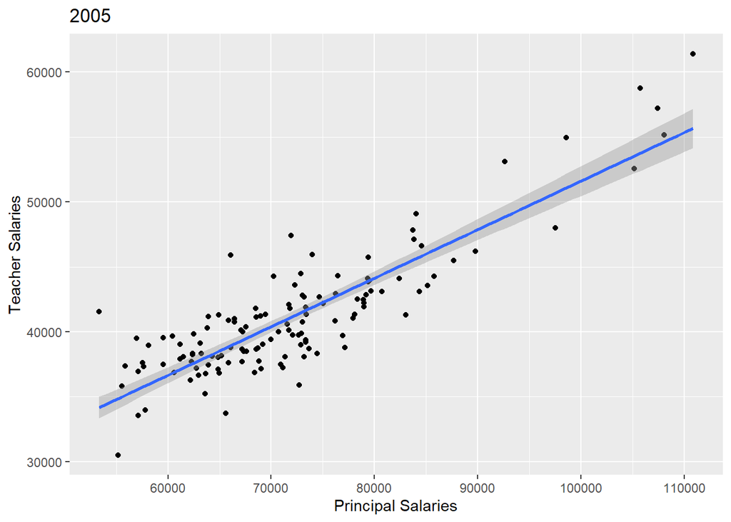

```r
salary_data %>%
  ggplot(aes(x = FY2005P, y = FY2005T)) +
  geom_point() +
  geom_smooth(method = "lm") +
  labs(title = "2005",  x = "Principal Salaries", y = "Teacher Salaries")
```

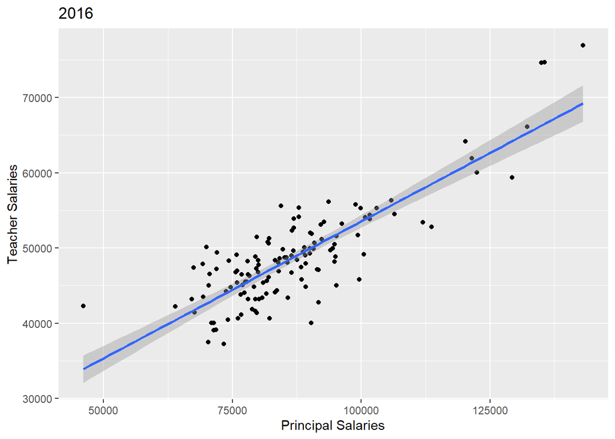

```r
salary_data %>%
  ggplot(aes(x = FY2016P, y = FY2016T)) +
  geom_point() +
  geom_smooth(method = "lm")+
  labs(title = "2016", x = "Principal Salaries", y = "Teacher Salaries")
```

Create Model for 2005

```r
fit_salary_2005 <- lm(FY2005T ~ FY2005P, data = salary_data)
summary(fit_salary_2005)
```

```
##
## Call:
## lm(formula = FY2005T ~ FY2005P, data = salary_data)
##
## Residuals:
##     Min      1Q  Median      3Q     Max
## -5518.3 -1595.5  -243.9  1463.4  7381.3
##
## Coefficients:
##              Estimate Std. Error t value Pr(>|t|)
## (Intercept) 1.426e+04  1.390e+03   10.26   <2e-16 ***
## FY2005P     3.734e-01  1.908e-02   19.57   <2e-16 ***
## ---
## Signif. codes:  0 '***' 0.001 '**' 0.01 '*' 0.05 '.' 0.1 ' ' 1
##
## Residual standard error: 2436 on 128 degrees of freedom
## Multiple R-squared:  0.7495, Adjusted R-squared:  0.7476
## F-statistic:   383 on 1 and 128 DF,  p-value: < 2.2e-16
```

Create Model for 2016

```r
fit_salary_2016 <- lm(FY2016T ~ FY2016P, data = salary_data)
summary(fit_salary_2016)
```

```
##
## Call:
## lm(formula = FY2016T ~ FY2016P, data = salary_data)
##
## Residuals:
##     Min      1Q  Median      3Q     Max
## -9932.8 -2885.3   220.9  2109.7  8378.9
##
## Coefficients:
##              Estimate Std. Error t value Pr(>|t|)
## (Intercept) 1.717e+04  1.859e+03   9.237    7e-16 ***
## FY2016P     3.636e-01  2.108e-02  17.247   <2e-16 ***
## ---
## Signif. codes:  0 '***' 0.001 '**' 0.01 '*' 0.05 '.' 0.1 ' ' 1
##
## Residual standard error: 3636 on 128 degrees of freedom
## Multiple R-squared:  0.6992, Adjusted R-squared:  0.6968
## F-statistic: 297.5 on 1 and 128 DF,  p-value: < 2.2e-16
```

Look for Outliers and/or Influential Cases 2005

```r
salary_data$residual05 <- resid(fit_salary_2005)
salary_data$standardized.residuals05 <- rstandard(fit_salary_2005)
salary_data$studentized.residuals05 <- rstudent(fit_salary_2005)
salary_data$cooks.distance05 <-cooks.distance(fit_salary_2005)
salary_data$dfbeta05 <- dfbeta(fit_salary_2005)
salary_data$dffit05 <- dffits(fit_salary_2005)
salary_data$leverage05 <- hatvalues(fit_salary_2005)
salary_data$covariance.ratios05 <- covratio(fit_salary_2005)

fit_salary_df <- salary_data %>%
  mutate(large.residual05 = case_when(standardized.residuals05 > 2 | standardized.residuals05 < -2 ~ TRUE,
                                    abs(standardized.residuals05) <= 2 ~ FALSE))

fit_salary_df %>% filter(large.residual05 == TRUE) %>% head()
```

```
##                          div_name FY2005P FY2016P FY2005T FY2016T residual05
## 1 Arlington County Public Schools  110868  143092   61407   76942   5750.309
## 2  Fauquier County Public Schools   71900   99861   47429   55298   6321.144
## 3   Russell County Public Schools   65615   71393   33725   39102  -5036.329
## 4  Alexandria City Public Schools  105745  135566   58759   74664   5014.998
## 5   Covington City Public Schools   66102   69973   45913   50119   6969.848
## 6  Portsmouth City Public Schools   72710   82151   35892   51310  -5518.272
##   standardized.residuals05 studentized.residuals05 cooks.distance05
## 1                 2.489123                2.541657       0.34554358
## 2                 2.605343                2.666819       0.02631164
## 3                -2.078413               -2.106122       0.02225084
## 4                 2.143814                2.174825       0.19313864
## 5                 2.875812                2.961838       0.04105001
## 6                -2.274462               -2.312778       0.02013132
##   dfbeta05.(Intercept) dfbeta05.FY2005P    dffit05  leverage05
## 1        -1.048097e+03     1.523884e-02  0.8488619 0.100349239
## 2         5.193859e+01    -4.079527e-05  0.2348106 0.007692976
## 3        -1.827471e+02     1.994419e-03 -0.2137667 0.010196749
## 4        -7.684376e+02     1.125288e-02  0.6305024 0.077531223
## 5         2.376701e+02    -2.548784e-03  0.2951022 0.009829521
## 6        -2.544520e+01    -2.407272e-04 -0.2040358 0.007722851
##   covariance.ratios05 large.residual05
## 1           1.0224536             TRUE
## 2           0.9179924             TRUE
## 3           0.9581732             TRUE
## 4           1.0235281             TRUE
## 5           0.8976074             TRUE
## 6           0.9426403             TRUE
```

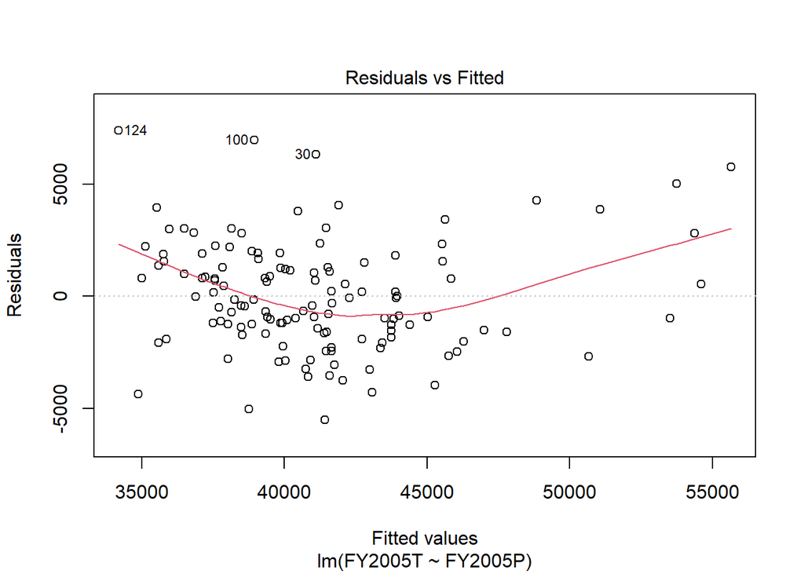

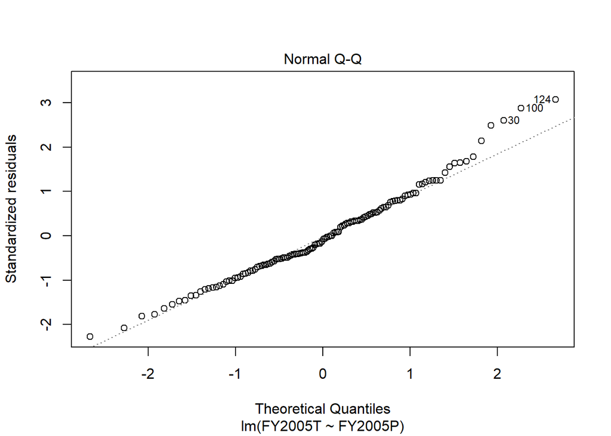

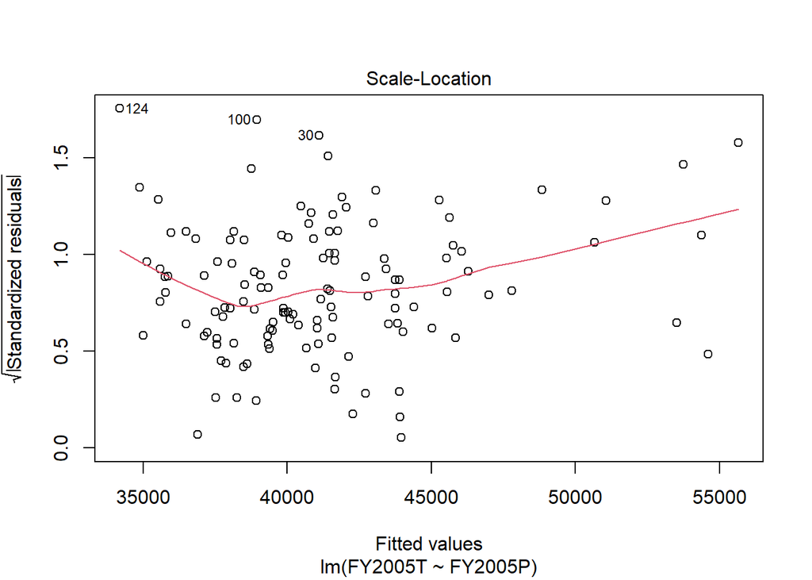

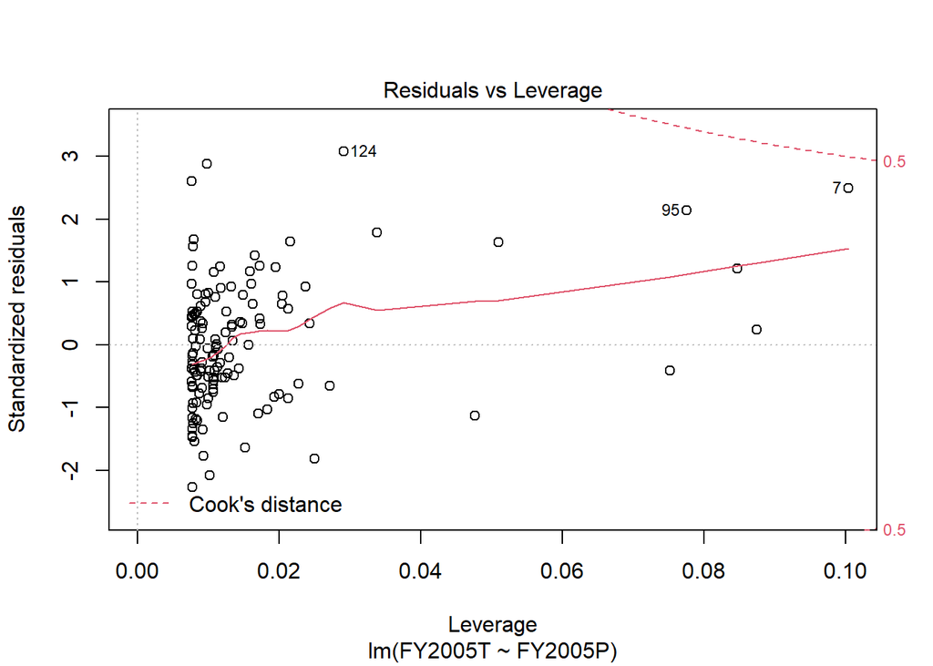

```r
plot(fit_salary_2005)
```

Look for Outliers and/or Influential Cases 2016

```r
salary_data$residual16 <- resid(fit_salary_2016)
salary_data$standardized.residuals16 <- rstandard(fit_salary_2016)
salary_data$studentized.residuals16 <- rstudent(fit_salary_2016)
salary_data$cooks.distance16 <-cooks.distance(fit_salary_2016)
salary_data$dfbeta16 <- dfbeta(fit_salary_2016)
salary_data$dffit16 <- dffits(fit_salary_2016)
salary_data$leverage16 <- hatvalues(fit_salary_2016)
salary_data$covariance.ratios16 <- covratio(fit_salary_2016)

fit_salary_df <- salary_data %>%
  mutate(large.residual16 = case_when(standardized.residuals16 > 2 | standardized.residuals16 < -2 ~ TRUE,
                                    abs(standardized.residuals16) <= 2 ~ FALSE))

fit_salary_df %>% filter(large.residual16 == TRUE) %>% head()
```

```
##                              div_name FY2005P FY2016P FY2005T FY2016T
## 1     Arlington County Public Schools  110868  143092   61407   76942
## 2      Campbell County Public Schools   77138   99601   38773   45822
## 3 Isle Of Wight County Public Schools   79694   84448   43147   55609
## 4       Madison County Public Schools   68567   91706   38675   42770
## 5      Alexandria City Public Schools  105745  135566   58759   74664
## 6     Buena Vista City Public Schools   62469   46084   39833   42310
##   residual05 standardized.residuals05 studentized.residuals05 cooks.distance05
## 1   5750.309                2.4891229               2.5416571     0.3455435769
## 2  -4290.481               -1.7698196              -1.7848665     0.0147161600
## 3   -870.772               -0.3595578              -0.3583315     0.0007400962
## 4  -1188.469               -0.4900218              -0.4885623     0.0010191482
## 5   5014.998                2.1438140               2.1748246     0.1931386436
## 6   2246.240                0.9284302               0.9279261     0.0057962510
##   dfbeta05.(Intercept) dfbeta05.FY2005P     dffit05  leverage05
```

[output cut: 27 more lines]

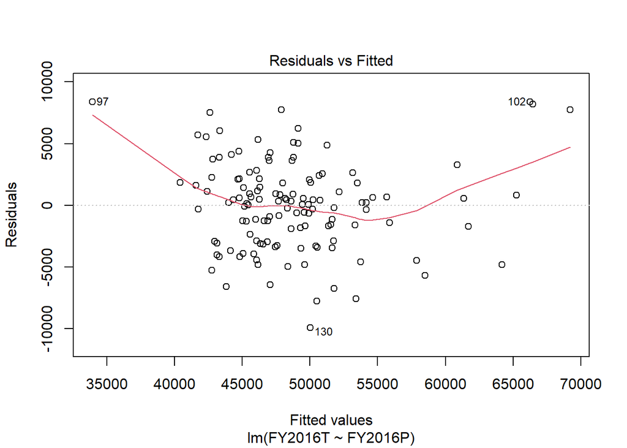

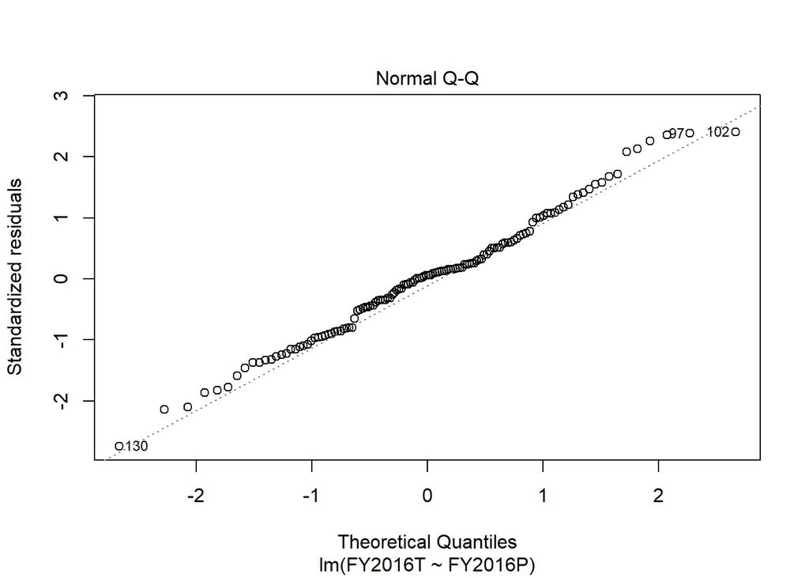

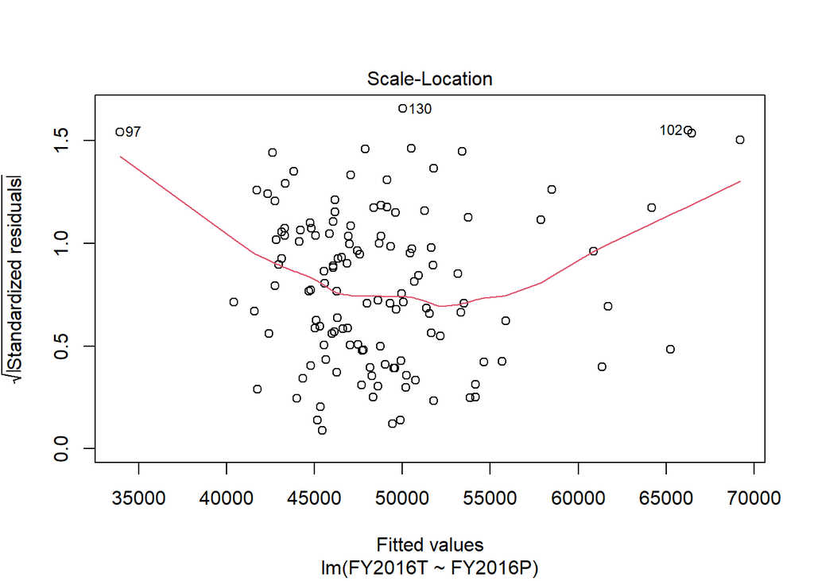

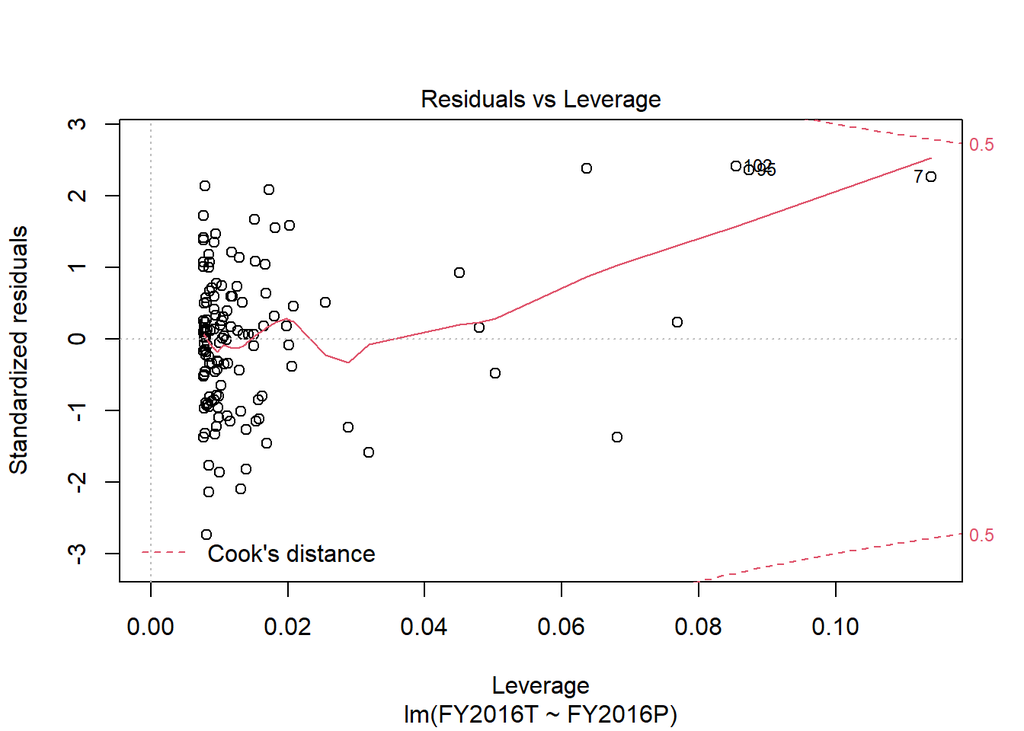

```r
plot(fit_salary_2016)
```

### Report on Results

For both the 2005 and 2016 the linear regression model significantly predicts a teacher’s salary given the principal’s salary. The table below shows the pertinent values.

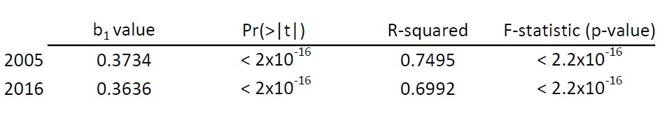

# ——Part 3——

Randomly divide the group of counties from (2) in two halves. Run a simple regression on each half. Compare the results from each of these two samples with what you know the population answers to be and discuss any differences you see in these two estimates of the true values and if the confidence intervals from these samples encompass the results of the original population regression from (2). Plot scatterplots of these different datasets with models and use ggplot to add the lines on too.

Let’s take our joined dataframe (salary_data) and split the 130 observations into two ramdom groups.

```r
set.seed(37645)
dummy_sep <- rbinom(nrow(salary_data), 1, 0.5)

salary_sample1 <- salary_data[dummy_sep == 0, ]
salary_sample2 <- salary_data[dummy_sep == 1, ]
```

Create a Linear Model on each set for 2005

```r
fit_salary1_2005 <- lm(FY2005T ~ FY2005P, data = salary_sample1)
summary(fit_salary1_2005)
```

```
##
## Call:
## lm(formula = FY2005T ~ FY2005P, data = salary_sample1)
##
## Residuals:
##     Min      1Q  Median      3Q     Max
## -4446.2 -1588.0  -221.3  1197.8  7521.7
##
## Coefficients:
##              Estimate Std. Error t value Pr(>|t|)
## (Intercept) 1.302e+04  1.844e+03    7.06  1.1e-09 ***
## FY2005P     3.941e-01  2.503e-02   15.74  < 2e-16 ***
## ---
## Signif. codes:  0 '***' 0.001 '**' 0.01 '*' 0.05 '.' 0.1 ' ' 1
##
## Residual standard error: 2430 on 68 degrees of freedom
## Multiple R-squared:  0.7847, Adjusted R-squared:  0.7816
## F-statistic: 247.9 on 1 and 68 DF,  p-value: < 2.2e-16
```

```r
fit_salary2_2005 <- lm(FY2005T ~ FY2005P, data = salary_sample2)
summary(fit_salary2_2005)
```

```
##
## Call:
## lm(formula = FY2005T ~ FY2005P, data = salary_sample2)
##
## Residuals:
##     Min      1Q  Median      3Q     Max
## -5160.5 -1494.3  -342.9  1689.0  6467.0
##
## Coefficients:
##              Estimate Std. Error t value Pr(>|t|)
## (Intercept) 1.631e+04  2.100e+03   7.767 1.51e-10 ***
## FY2005P     3.402e-01  2.920e-02  11.650  < 2e-16 ***
## ---
## Signif. codes:  0 '***' 0.001 '**' 0.01 '*' 0.05 '.' 0.1 ' ' 1
##
## Residual standard error: 2407 on 58 degrees of freedom
## Multiple R-squared:  0.7006, Adjusted R-squared:  0.6954
## F-statistic: 135.7 on 1 and 58 DF,  p-value: < 2.2e-16
```

Create Plots for 2005

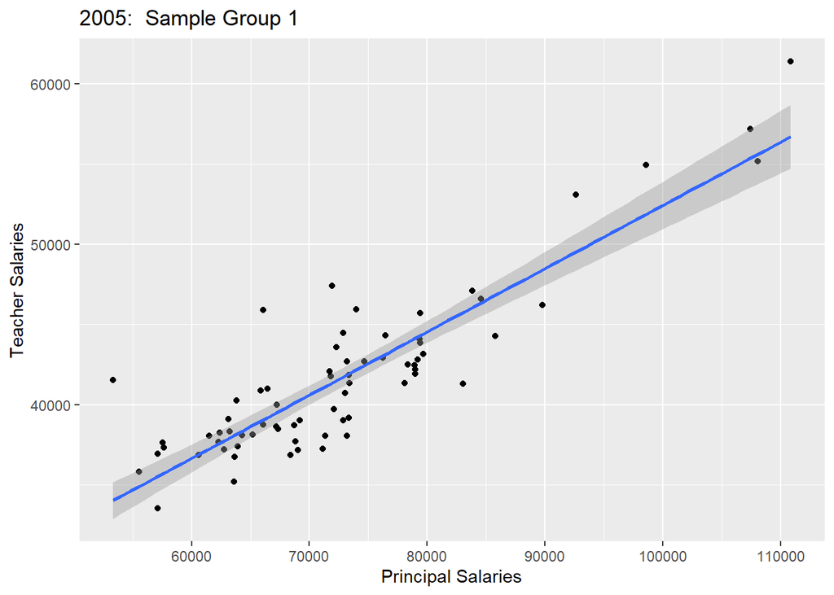

```r
salary_sample1 %>%
  ggplot(aes(x = FY2005P, y = FY2005T)) +
  geom_point() +
  geom_smooth(method = "lm") +
  labs(title = "2005:  Sample Group 1",  x = "Principal Salaries", y = "Teacher Salaries")
```

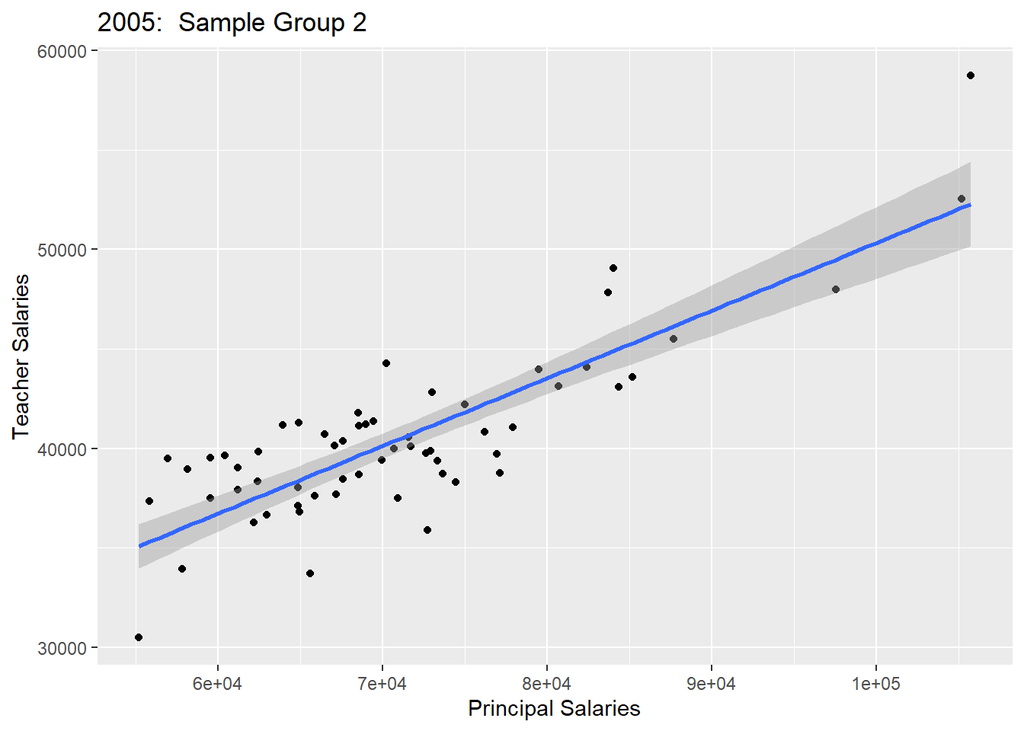

```r
salary_sample2 %>%
  ggplot(aes(x = FY2005P, y = FY2005T)) +
  geom_point() +
  geom_smooth(method = "lm")+
  labs(title = "2005:  Sample Group 2", x = "Principal Salaries", y = "Teacher Salaries")
```

Confidence Intervals of Samples (compare to Population b0 = 14260 and b1= 0.374)

```r
confint(fit_salary1_2005, level = 0.95)
```

```
##                   2.5 %       97.5 %
## (Intercept) 9338.923271 1.669778e+04
## FY2005P        0.344128 4.440153e-01
```

```r
confint(fit_salary2_2005, level = 0.95)
```

```
##                    2.5 %       97.5 %
## (Intercept) 1.210957e+04 2.051874e+04
## FY2005P     2.817734e-01 3.986917e-01
```

### Report on Results

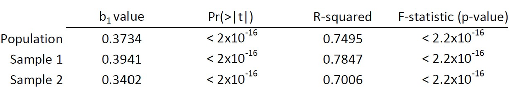

Interpretation:

- The table above compares the samples with the population.
- While there are differences in the regression coefficients from the two samples and the population, the 95% confidence intervals for each sample include the regression coefficients of the population.

# ——Part 4——

Run a multiple regression. Choose an outcome variable of interest from the one of the degree percentage variables. Choose one predictor variable from the tables provided to pretend it is the theory variable. Choose two additional predictor variables from the tables to be the “additional” possible predictor variables. Interpret the results of the models and discuss how good a fit are the models, including whether or not the second level model is better than the first. Discuss in practical terms how to interpret the regression coefficient. Evaluate if there are any outliers and adjust the model if needed. Compute relevant diagnostics, produce and interpret plots, etc. to demonstrate your knowledge of various means of checking assumptions.

Read in the new data, select the relevant columns, ensure the data are numbers, and join data.

```r
VA_chars <- read.csv("VA_characteristics.csv", header = TRUE)

VA_chars_sub <- VA_chars %>%
  select(Locality, HS2015, Comp_index_2014_2016, PerPovertyBelow50)

degree_sub <- all_degrees %>%
  select(div_name, X.STEMHall)

names(VA_chars_sub)[1] <- "div_name"

VA_chars_sub <- VA_chars_sub %>%
  mutate_at(vars(starts_with ("HS")), as.numeric)

VA_chars_sub <- VA_chars_sub %>%
  mutate_at(vars(starts_with ("Comp")), as.numeric)

VA_chars_sub <- VA_chars_sub %>%
  mutate_at(vars(starts_with ("PerPo")), as.numeric)


char_degree <- inner_join(VA_chars_sub, degree_sub, by = "div_name")

char_degree <- char_degree[-c(29), ]
```

Using the Hierarchical method I am going to start using ontime high school graduation rates to predict the percent of STEM-H degrees in higher education institutions.

```r
fit_single_degree <- lm(X.STEMHall ~ HS2015, data = char_degree)
summary(fit_single_degree)
```

```
##
## Call:
## lm(formula = X.STEMHall ~ HS2015, data = char_degree)
##
## Residuals:
##       Min        1Q    Median        3Q       Max
## -0.109218 -0.032029 -0.008957  0.027886  0.187994
##
## Coefficients:
##             Estimate Std. Error t value Pr(>|t|)
## (Intercept)   0.6749     0.1400   4.821 5.62e-06 ***
## HS2015       -0.3702     0.1537  -2.409    0.018 *
## ---
## Signif. codes:  0 '***' 0.001 '**' 0.01 '*' 0.05 '.' 0.1 ' ' 1
##
## Residual standard error: 0.05471 on 92 degrees of freedom
## Multiple R-squared:  0.05933,    Adjusted R-squared:  0.0491
## F-statistic: 5.802 on 1 and 92 DF,  p-value: 0.018
```

Plot linear regression

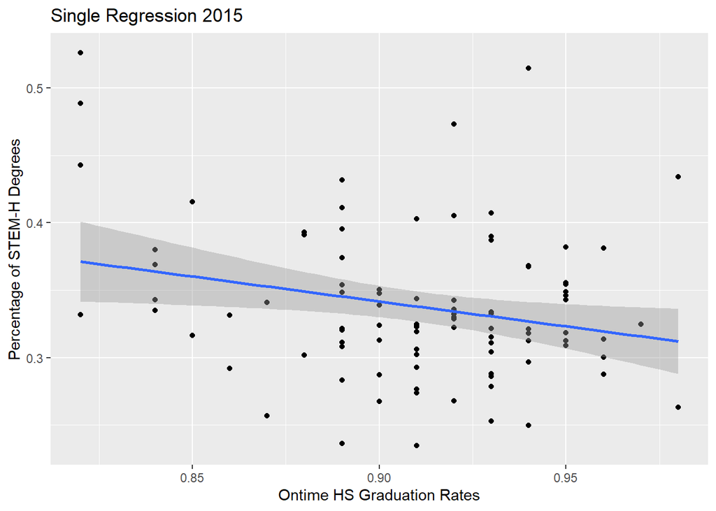

```r
char_degree %>%
  ggplot(aes(x = HS2015, y = X.STEMHall)) +
  geom_point() +
  geom_smooth(method = "lm") +
  labs(title = "Single Regression 2015",  x = "Ontime HS Graduation Rates", y = "Percentage of STEM-H Degrees")
```

Create a multiple linear regression model to predict the percent of STEM-H degrees and higher education using Ontime HS graduation rates, Virginia Composite Index, and percent of children ages 0-17 living below 50% of the federal poverty level.

```r
fit_multiple_degree <- lm(formula = X.STEMHall ~ HS2015 + Comp_index_2014_2016 + PerPovertyBelow50, data = char_degree)
summary(fit_multiple_degree)
```

```
##
## Call:
## lm(formula = X.STEMHall ~ HS2015 + Comp_index_2014_2016 + PerPovertyBelow50,
##     data = char_degree)
##
## Residuals:
##       Min        1Q    Median        3Q       Max
## -0.126676 -0.036390 -0.007052  0.034501  0.171266
##
## Coefficients:
##                       Estimate Std. Error t value Pr(>|t|)
## (Intercept)           0.545824   0.155712   3.505 0.000713 ***
## HS2015               -0.254442   0.168026  -1.514 0.133454
## Comp_index_2014_2016  0.010376   0.038357   0.271 0.787378
## PerPovertyBelow50     0.002319   0.001241   1.869 0.064920 .
## ---
## Signif. codes:  0 '***' 0.001 '**' 0.01 '*' 0.05 '.' 0.1 ' ' 1
##
## Residual standard error: 0.05426 on 90 degrees of freedom
## Multiple R-squared:  0.09475,    Adjusted R-squared:  0.06457
## F-statistic:  3.14 on 3 and 90 DF,  p-value: 0.02919
```

```r
char_degree$residual <- resid(fit_multiple_degree)
char_degree$standardized.residuals <- rstandard(fit_multiple_degree)
char_degree$studentized.residuals <- rstudent(fit_multiple_degree)
char_degree$cooks.distance <-cooks.distance(fit_multiple_degree)
char_degree$dfbeta <- dfbeta(fit_multiple_degree)
char_degree$dffit <- dffits(fit_multiple_degree)
char_degree$leverage <- hatvalues(fit_multiple_degree)
char_degree$covariance.ratios <- covratio(fit_multiple_degree)

fit_multiple_df <- char_degree %>%
  mutate(large.residual = case_when(standardized.residuals > 2 | standardized.residuals < -2 ~ TRUE,
                                    abs(standardized.residuals) <= 2 ~ FALSE))

fit_multiple_df %>% filter(large.residual == TRUE) %>% head()
```

```
##              div_name HS2015 Comp_index_2014_2016 PerPovertyBelow50 X.STEMHall
## 1 Charles City County   0.98                 0.44              10.4     0.4341
## 2   Cumberland County   0.91                 0.28              19.1     0.2348
## 3    Dickenson County   0.82                 0.27              12.0     0.4889
## 4        Henry County   0.89                 0.24              11.6     0.2362
## 5          Lee County   0.82                 0.19              19.5     0.5264
## 6        Scott County   0.94                 0.19              15.1     0.5149
##     residual standardized.residuals studentized.residuals cooks.distance
## 1  0.1089482               2.077233              2.117033     0.07593258
## 2 -0.1266758              -2.417356             -2.485948     0.10558595
## 3  0.1210915               2.322225              2.381746     0.11178266
## 4 -0.1125588              -2.098911             -2.140256     0.02627950
## 5  0.1420308               2.752020              2.859653     0.19971396
## 6  0.1712664               3.268408              3.462157     0.19324507
##   dfbeta.(Intercept) dfbeta.HS2015 dfbeta.Comp_index_2014_2016
```

[output cut: 20 more lines]

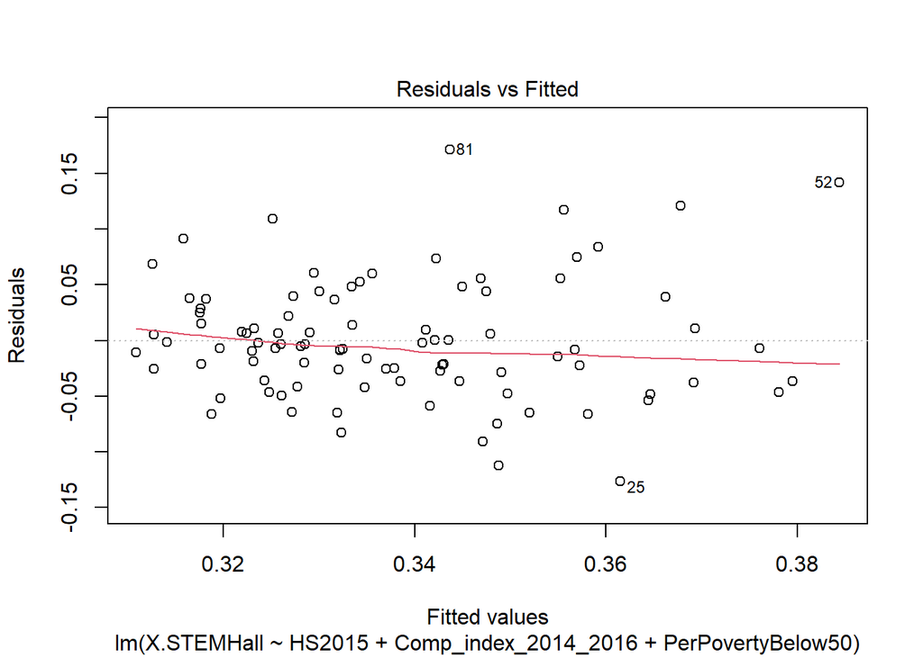

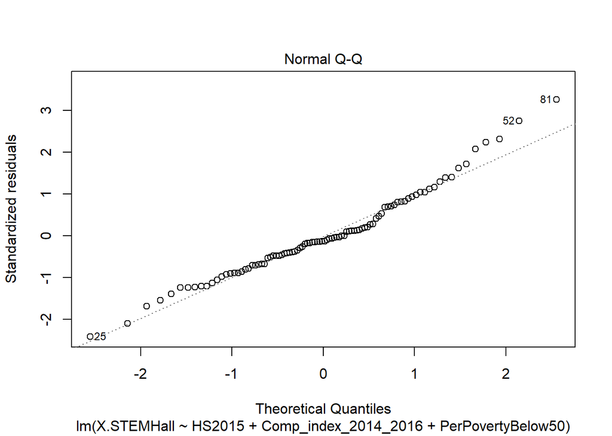

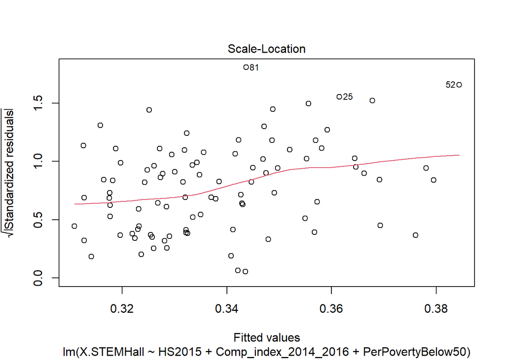

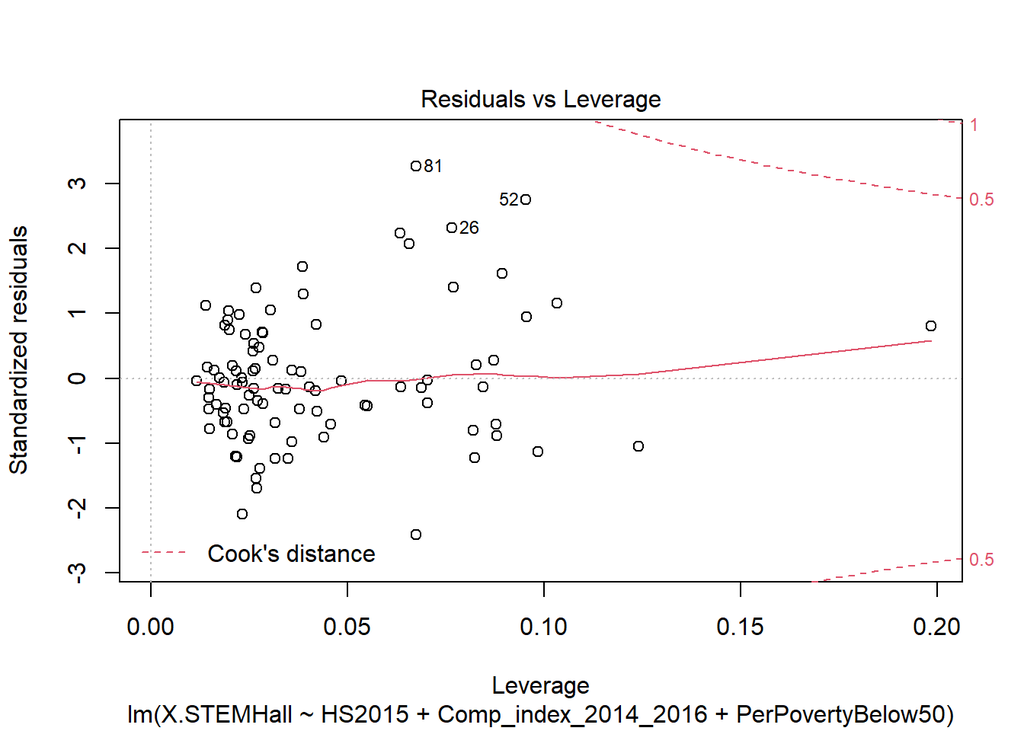

```r
plot(fit_multiple_degree)
```

Check for outliers

```r
fit_multiple_df$large.residual <- fit_multiple_df$standardized.residuals > 2 | fit_multiple_df$standardized.residuals < -2
fit_multiple_df[fit_multiple_df$large.residual,c("div_name", "HS2015", "Comp_index_2014_2016", "PerPovertyBelow50", "X.STEMHall", "standardized.residuals")]
```

```
##               div_name HS2015 Comp_index_2014_2016 PerPovertyBelow50 X.STEMHall
## 19 Charles City County   0.98                 0.44              10.4     0.4341
## 25   Cumberland County   0.91                 0.28              19.1     0.2348
## 26    Dickenson County   0.82                 0.27              12.0     0.4889
## 45        Henry County   0.89                 0.24              11.6     0.2362
## 52          Lee County   0.82                 0.19              19.5     0.5264
## 81        Scott County   0.94                 0.19              15.1     0.5149
## 93         Wise County   0.92                 0.25              17.8     0.4731
##    standardized.residuals
## 19               2.077233
## 25              -2.417356
## 26               2.322225
## 45              -2.098911
## 52               2.752020
## 81               3.268408
## 93               2.237307
```

There are 94 observations and 7 (7.4%) of them have large residuals. We will investigate this further.

Leverage, Cooks Distance, and Covariance Ratio for the 7 cases

```r
fit_multiple_df[fit_multiple_df$large.residual,c("cooks.distance", "leverage", "covariance.ratios", "standardized.residuals")]
```

```
##    cooks.distance   leverage covariance.ratios standardized.residuals
## 19     0.07593258 0.06576202         0.9196101               2.077233
## 25     0.10558595 0.06740294         0.8572239              -2.417356
## 26     0.11178266 0.07656531         0.8844322               2.322225
## 45     0.02627950 0.02330495         0.8759230              -2.098911
## 52     0.19971396 0.09541462         0.8133088               2.752020
## 81     0.19324507 0.06747695         0.6764827               3.268408
## 93     0.08465984 0.06336596         0.8880398               2.237307
```

Assessing the Assumption of Independence

```r
dwt(fit_multiple_degree)
```

```
##  lag Autocorrelation D-W Statistic p-value
##    1     -0.07681541      2.150978   0.482
##  Alternative hypothesis: rho != 0
```

Assumption of Multicollinearity

```r
vif(fit_multiple_degree)
```

```
##               HS2015 Comp_index_2014_2016    PerPovertyBelow50
##             1.214825             1.130747             1.256578
```

```r
mean(vif(fit_multiple_degree))
```

```
## [1] 1.200716
```

```r
1/vif(fit_multiple_degree)
```

```
##               HS2015 Comp_index_2014_2016    PerPovertyBelow50
##            0.8231641            0.8843712            0.7958122
```

- Analysis
  - Since none of the cases have a VIF greater than 10 there is no cause for concern.
  - The average VIF is not substantially greater than 1 so the regression is not biased
  - The tolerance is not below 0.2. We can safely conclude that there is no collinieary within out data.

Assumption about Residuals

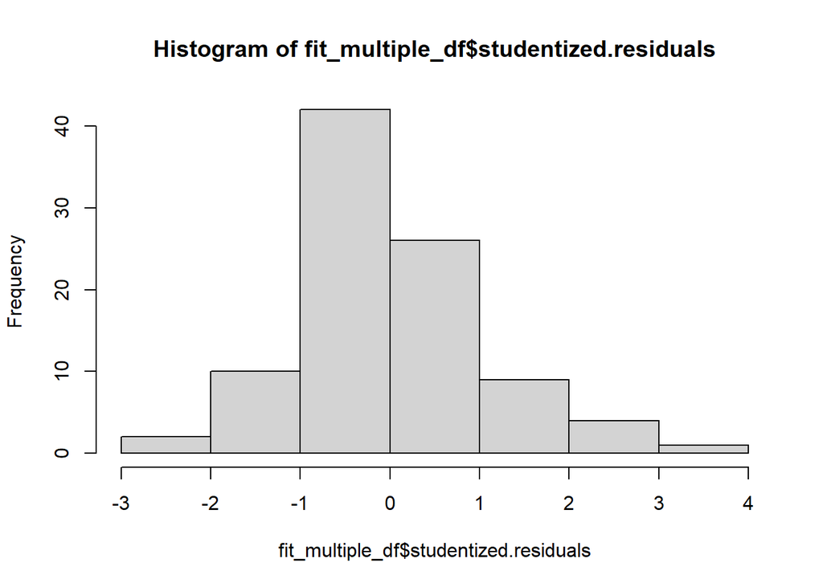

```r
hist(fit_multiple_df$studentized.residuals)
```

By inspection of the histogram and qqplot the sample looks like a normal distribution.

### Report on Results

The practical significance of the regression coefficients are as follows:

- The negative b1 value associated with high school graduation rates indicates an indirect relationship between high school graduation rates and percent of STEM-H degrees - as one increases/decreases that causes the opposite motion (decrease/increase) in the other. This model indicates that with a 4% increase in high school graduation rates the percent of STEM-H degrees would decrease by 1%.
- The positive b1 value associated with Composite Index indicates a direct relationship between Composite Index and percent of STEM-H degrees - as one increases/decreases that causes an increase/decrease in the other. This model indicates that with a 1 point increase in Composite Index the percent of STEM-H degrees would increase by 0.01.
- The positive b1 value associated with Perfect of children living below poverty level indicates a direct relationship between the percent living under the poverty level and percent of STEM-H degrees - as one increases/decreases that causes an increase/decrease in the other. This model indicates that with a 1 point increase in percent poverty the percent of STEM-H degrees would increase by 0.002.

Logically this doesn’t make much sense particularly with the last predictor which is another indication that the model is not a good fit.